# Preparing the dataset for hippocampus segmentation

In this notebook you will use the skills and methods that we have talked about during our EDA Lesson to prepare the hippocampus dataset using Python. Follow the Notebook, writing snippets of code where directed so using Task comments, similar to the one below, which expects you to put the proper imports in place. Write your code directly in the cell with TASK comment. Feel free to add cells as you see fit, but please make sure that code that performs that tasked activity sits in the same cell as the Task comment.

```python
from IPython.display import display, Markdown, clear_output

# import the libraries
import nibabel as nib
import matplotlib.pyplot as plt
import numpy as np

# import extra libraries
import os
import sys
import glob
import shutil
import pickle
from collections import Counter
from ipywidgets import *

#!!!!!!!!!!!!!!!!!!!!!!!!!!!!!!!!!!!!!!!!!!!!!!!!!!!!!!!!!!!!!!!!!!!!!!!!!!!!!!!!!!!!!!
# install package                                                                   !!!
# ! It might be that you've to restart your kernel after installing pandas and ploty!!!
#!!!!!!!!!!!!!!!!!!!!!!!!!!!!!!!!!!!!!!!!!!!!!!!!!!!!!!!!!!!!!!!!!!!!!!!!!!!!!!!!!!!!!!
!{sys.executable} -m pip install pandas plotly ipympl
import pandas as pd
import plotly.express as px
pd.set_option('display.max_columns', 500)
pd.set_option('display.width', 1000)

# allow images
%matplotlib inline

# clear  log
clear_output()
```

It will help your understanding of the data a lot if you were able to use a tool that allows you to view NIFTI volumes, like [3D Slicer](https://www.slicer.org/). I will refer to Slicer throughout this Notebook and will be pasting some images showing what your output might look like.

## Loading NIFTI images using NiBabel

NiBabel is a python library for working with neuro-imaging formats (including NIFTI) that we have used in some of the exercises throughout the course. Our volumes and labels are in NIFTI format, so we will use nibabel to load and inspect them.

NiBabel documentation could be found here: https://nipy.org/nibabel/

Our dataset sits in two directories - *images* and *labels*. Each image is represented by a single file (we are fortunate to have our data converted to NIFTI) and has a corresponding label file which is named the same as the image file.

Note that our dataset is "dirty". There are a few images and labels that are not quite right. They should be quite obvious to notice, though. The dataset contains an equal amount of "correct" volumes and corresponding labels, and you don't need to alter values of any samples in order to get the clean dataset.

```python
#------------------#
# locate the paths #
#------------------#
path = '/data/TrainingSet'
images_path = sorted(glob.glob(f'{path}/images/*.nii.gz'))
labels_path = sorted(glob.glob(f'{path}/labels/*.nii.gz'))

#------------------#
# combine the data #
#------------------#
# take the intersection of the data
tmp_counter = Counter()
for path_image, path_label in zip(images_path, labels_path):
    tmp_counter[path_image.rsplit('/',1)[1]] += 1
    tmp_counter[path_label.rsplit('/',1)[1]] += 1

data = {}
for item, value in tmp_counter.items():
    if value != 2:
        continue

    data[item] = {'label_path': f'{path}/labels/{item}',
                  'image_path': f'{path}/images/{item}'}

    # load label
    data[item]['label'] = nib.load(data[item]['label_path'])
    data[item]['label_data'] = data[item]['label'].get_fdata()

    # load image
    data[item]['image'] = nib.load(data[item]['image_path'])
    data[item]['image_data'] = data[item]['image'].get_fdata()

#------------#
# Print info #
#------------#
text = ''
text += '<b>Images</b>  \n'
text += f'Amount of images: {len(images_path)}  \n'
text += f'Examples:  \n'
for p in images_path[:3]:
    text += f'- {p}  \n'
text += '  \n'

text += '<b>Labels</b>  \n'
text += f'Amount of labels: {len(labels_path)}  \n'
text += f'Examples:  \n'
for p in labels_path[:3]:
    text += f'- {p}  \n'
text += '  \n'

text += '<b>Intersection of Images & Labels</b>  \n'
text += f'Amount of labels: {len(data)}  \n'
# show info
display(Markdown(text))

# info about the images
info = []
for item, img, lbl in zip( list(data), [v['image_data'] for _, v in data.items()], [v['label_data'] for _, v in data.items()]):
    info.append({'name': item,
                 'image_shape': img.shape,
                 'image_max_pixel_value': np.around(img.max(),0),
                 'image_mean_pixel_value': np.around(img.mean(),0),
                 'image_std_pixel_value': np.around(img.std(),2),
                 'label_shape': lbl.shape,
                 'label_max_pixel_value': np.around(lbl.max(),0),
                 'label_mean_pixel_value': np.around(lbl.mean(),0),
                 'label_std_pixel_value': np.around(lbl.std(),2),
                 'slice_inonsistency': img.shape[0] != lbl.shape[0]})

info = pd.DataFrame(info).sort_values(['image_shape'], ascending=False).reset_index(drop=True)
display(info)
```

**Images**  
Amount of images: 263  
Examples:

- /data/TrainingSet/images/hippocampus_001.nii.gz

- /data/TrainingSet/images/hippocampus_003.nii.gz

- /data/TrainingSet/images/hippocampus_004.nii.gz

**Labels**  
Amount of labels: 262  
Examples:

- /data/TrainingSet/labels/hippocampus_001.nii.gz

- /data/TrainingSet/labels/hippocampus_003.nii.gz

- /data/TrainingSet/labels/hippocampus_004.nii.gz

**Intersection of Images & Labels**  
Amount of labels: 261

|  | name | image_shape | image_max_pixel_value | image_mean_pixel_value | image_std_pixel_value | label_shape | label_max_pixel_value | label_mean_pixel_value | label_std_pixel_value | slice_inonsistency |
| --- | --- | --- | --- | --- | --- | --- | --- | --- | --- | --- |
| 0 | hippocampus_010.nii.gz | (512, 512, 241) | 3071.0 | -593.0 | 487.35 | (36, 50, 31) | 2.0 | 0.0 | 0.37 | True |
| 1 | hippocampus_281.nii.gz | (512, 512, 31) | 1166.0 | -429.0 | 485.81 | (512, 512, 94) | 1.0 | 0.0 | 0.03 | False |
| 2 | hippocampus_125.nii.gz | (43, 42, 39) | 254.0 | 69.0 | 29.86 | (43, 42, 39) | 2.0 | 0.0 | 0.29 | False |
| 3 | hippocampus_015.nii.gz | (42, 51, 28) | 1682.0 | 440.0 | 215.39 | (42, 51, 28) | 2.0 | 0.0 | 0.33 | False |
| 4 | hippocampus_164.nii.gz | (41, 48, 47) | 187.0 | 63.0 | 27.60 | (41, 48, 47) | 2.0 | 0.0 | 0.33 | False |
| ... | ... | ... | ... | ... | ... | ... | ... | ... | ... | ... |
| 256 | hippocampus_138.nii.gz | (32, 46, 42) | 907688.0 | 200259.0 | 87593.95 | (32, 46, 42) | 2.0 | 0.0 | 0.32 | False |
| 257 | hippocampus_143.nii.gz | (32, 45, 41) | 167.0 | 55.0 | 22.32 | (32, 45, 41) | 2.0 | 0.0 | 0.31 | False |
| 258 | hippocampus_343.nii.gz | (32, 45, 38) | 1009.0 | 479.0 | 217.93 | (32, 45, 38) | 2.0 | 0.0 | 0.36 | False |
| 259 | hippocampus_265.nii.gz | (31, 54, 34) | 2008.0 | 509.0 | 253.69 | (31, 54, 34) | 2.0 | 0.0 | 0.37 | False |
| 260 | hippocampus_301.nii.gz | (31, 50, 36) | 3495.0 | 546.0 | 231.17 | (31, 50, 36) | 2.0 | 0.0 | 0.39 | False |

261 rows × 10 columns

```python
def show_raw_data():
    @interact(Sample=list(data))
    def f(Sample):

        sample = data[Sample]
        @interact(Slice=widgets.IntSlider(min=0, max=min(sample['label_data'].shape)-1, value=min(sample['label_data'].shape)//2))
        def g(Slice):

            for e in range(3):
                if e == 0:
                    # load the image
                    img_1 = data[Sample]['image_data'][Slice, :, :]
                    img_2 = data[Sample]['label_data'][Slice, :, :]
                elif e == 1:
                    # load the image
                    img_1 = data[Sample]['image_data'][:, Slice, :]
                    img_2 = data[Sample]['label_data'][:, Slice, :]
                else:
                    # load the image
                    img_1 = data[Sample]['image_data'][:, :, Slice]
                    img_2 = data[Sample]['label_data'][:, :, Slice]

                # overlay image 2 on image 1
                img_3 = (img_1 - img_1.min()) / (img_1.max() - img_1.min()) * 255 # normalize the image between 0 - 255
                img_3 = np.concatenate([img_3[:,:,None]] *3, axis=2).astype(int) # create 3 channels
                if img_2.max() > 0: # add image 2 if it contains any values
                    img_3[:,:,0] += ((img_2 - img_2.min()) / (img_2.max() - img_2.min()) * 100).astype(int)
                    img_3[img_3>255] = 255 # clip the values

                # plot
                plt.figure(figsize=(10,10))
                plt.subplot(1,3,1)
                plt.title(f'{"Sagittal" if e == 0 else "Coronal" if e== 1 else "Axial"}: Image')
                plt.imshow(img_1, cmap='gray')

                plt.subplot(1,3,2)
                plt.title(f'{"Sagittal" if e == 0 else "Coronal" if e== 1 else "Axial"}: Label')
                plt.imshow(img_2, cmap='gray')

                plt.subplot(1,3,3)
                plt.title(f'{"Sagittal" if e == 0 else "Coronal" if e== 1 else "Axial"}: Overlap')
                plt.imshow(img_3, cmap='gray')
                plt.show()
```

```python
show_raw_data()
```

```python
show_raw_data()
```

Load volume into 3D Slicer to validate that your visualization is correct and get a feel for the shape of structures.Try to get a visualization like the one below (hint: while Slicer documentation is not particularly great, there are plenty of YouTube videos available! Just look it up on YouTube if you are not sure how to do something)

[figure not shown]

```python
# Stand out suggestion: use one of the simple Volume Rendering algorithms that we've
# implemented in one of our earlier lessons to visualize some of these volumes
```

## Looking at single image data

In this section we will look closer at the NIFTI representation of our volumes. In order to measure the physical volume of hippocampi, we need to understand the relationship between the sizes of our voxels and the physical world.

```python
# Nibabel supports many imaging formats, NIFTI being just one of them. I told you that our images
# are in NIFTI, but you should confirm if this is indeed the format that we are dealing with

# image or label
focus = 'image'

info = []
for k, v in data.items():
    info.append({ 'item': k,
                  'format of image' : v[focus].header_class,
                  'bits per pixel': v[focus].header['bitpix'],
                  'units of measurement': v[focus].header.get_xyzt_units(),
                  'grid type': str(v[focus].header['regular'])[-2:-1],
                  'grid spacings': tuple(v[focus].header['pixdim']),
                  'label_volume': np.count_nonzero(v["label_data"])})

info = pd.DataFrame(info)
info
```

|  | item | format of image | bits per pixel | units of measurement | grid type | grid spacings | label_volume |
| --- | --- | --- | --- | --- | --- | --- | --- |
| 0 | hippocampus_001.nii.gz | <class 'nibabel.nifti1.Nifti1Header'> | 8 | (mm, sec) | r | (1.0, 1.0, 1.0, 1.0, 1.0, 0.0, 0.0, 0.0) | 2948 |
| 1 | hippocampus_003.nii.gz | <class 'nibabel.nifti1.Nifti1Header'> | 32 | (mm, sec) | r | (1.0, 1.0, 1.0, 1.0, 1.0, 0.0, 0.0, 0.0) | 3353 |
| 2 | hippocampus_004.nii.gz | <class 'nibabel.nifti1.Nifti1Header'> | 32 | (mm, sec) | r | (1.0, 1.0, 1.0, 1.0, 1.0, 0.0, 0.0, 0.0) | 3698 |
| 3 | hippocampus_006.nii.gz | <class 'nibabel.nifti1.Nifti1Header'> | 32 | (mm, sec) | r | (1.0, 1.0, 1.0, 1.0, 1.0, 0.0, 0.0, 0.0) | 4263 |
| 4 | hippocampus_007.nii.gz | <class 'nibabel.nifti1.Nifti1Header'> | 32 | (mm, sec) | r | (1.0, 1.0, 1.0, 1.0, 1.0, 0.0, 0.0, 0.0) | 3372 |
| ... | ... | ... | ... | ... | ... | ... | ... |
| 256 | hippocampus_386.nii.gz | <class 'nibabel.nifti1.Nifti1Header'> | 32 | (mm, sec) | r | (1.0, 1.0, 1.0, 1.0, 1.0, 0.0, 0.0, 0.0) | 3208 |
| 257 | hippocampus_387.nii.gz | <class 'nibabel.nifti1.Nifti1Header'> | 32 | (mm, sec) | r | (1.0, 1.0, 1.0, 1.0, 1.0, 0.0, 0.0, 0.0) | 3080 |
| 258 | hippocampus_389.nii.gz | <class 'nibabel.nifti1.Nifti1Header'> | 32 | (mm, sec) | r | (1.0, 1.0, 1.0, 1.0, 1.0, 0.0, 0.0, 0.0) | 2947 |
| 259 | hippocampus_390.nii.gz | <class 'nibabel.nifti1.Nifti1Header'> | 32 | (mm, sec) | r | (1.0, 1.0, 1.0, 1.0, 1.0, 0.0, 0.0, 0.0) | 3252 |
| 260 | hippocampus_393.nii.gz | <class 'nibabel.nifti1.Nifti1Header'> | 32 | (mm, sec) | r | (1.0, 1.0, 1.0, 1.0, 1.0, 0.0, 0.0, 0.0) | 3682 |

261 rows × 7 columns

```python
# TASK: using .header_class attribute - what is the format of our images?
info['format of image'].value_counts().reset_index()
```

|  | index | format of image |
| --- | --- | --- |
| 0 | <class 'nibabel.nifti1.Nifti1Header'> | 261 |

Further down we will be inspecting .header attribute that provides access to NIFTI metadata. You can use this resource as a reference for various fields: https://brainder.org/2012/09/23/the-nifti-file-format/

```python
# TASK: How many bits per pixel are used?
info['bits per pixel'].value_counts().reset_index()
```

|  | index | bits per pixel |
| --- | --- | --- |
| 0 | 32 | 206 |
| 1 | 8 | 55 |

```python
# TASK: What are the units of measurement?
info['units of measurement'].value_counts().reset_index()
```

|  | index | units of measurement |
| --- | --- | --- |
| 0 | (mm, sec) | 261 |

```python
# TASK: Do we have a regular grid? What are grid spacings?
display(info['grid type'].value_counts().reset_index())
display(info['grid spacings'].value_counts().reset_index())
print("We've regular grids")
```

|  | index | grid type |
| --- | --- | --- |
| 0 | r | 261 |

|  | index | grid spacings |
| --- | --- | --- |
| 0 | (1.0, 1.0, 1.0, 1.0, 1.0, 0.0, 0.0, 0.0) | 259 |
| 1 | (1.0, 0.785156, 0.785156, 7.5, 0.0, 0.0, 0.0, ... | 1 |
| 2 | (-1.0, 0.597656, 0.597656, 1.25, 0.0, 0.0, 0.0... | 1 |

```
We've regular grids
```

```python
# TASK: What dimensions represent axial, sagittal, and coronal slices? How do you know?
```

The field short dim[8] contains the size of the image array.  
The first element (dim[0]) contains the number of dimensions (1-7)  
The dimensions 1, 2 and 3 are assumed to refer to space (x, y, z)

- http://dicomiseasy.blogspot.com/2013/06/getting-oriented-using-image-plane.html

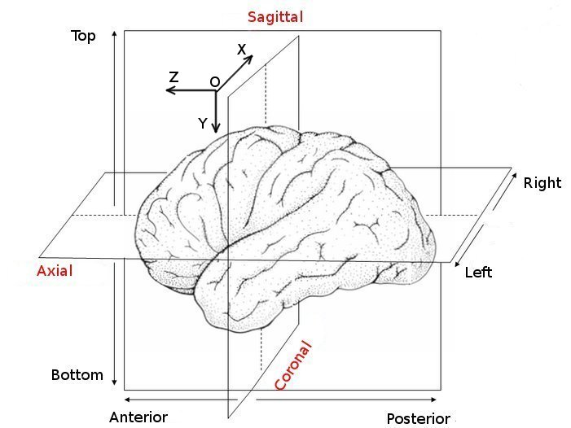

```python
# By now you should have enough information to decide what are dimensions of a single voxel
# TASK: Compute the volume (in mm³) of a hippocampus using one of the labels you've loaded.
# You should get a number between ~2200 and ~4500

# contains a outlier
pd.options.plotting.backend = "plotly"

tmp = info.label_volume.value_counts().sort_index().reset_index()
tmp.columns = ['Volume', 'Amount']

px.scatter(tmp,
           x='Volume',
           y='Amount',
           labels={ "Amount": "Amount",
                    "Volume": "Volume mm³"},
           title="Volume and their amount")
```

[interactive chart not shown]

## Plotting some charts

```python
display(px.scatter(pd.DataFrame([{"volume": r.label_volume,
                                  'random jitter': np.random.uniform(52,71),
                                  'file': r['item']} for _, r in info.iterrows()]),
           x='random jitter',
           y='volume',
           hover_data=['file'],
           labels={"volume":"volume mm³"}))

info.label_volume.plot(kind='hist', nbins=100)
```

[interactive chart not shown]

[figure not shown]

Do you see any outliers? Why do you think it's so (might be not immediately obvious, but it's always a good idea to inspect) outliers closer. If you haven't found the images that do not belong, the histogram may help you.

We do indeed have an outlier with a volume of more than 20K. (file 281)  
And if we remove / ignore that outlier (by selecting the dense areas in the plotly images) then we do not see any anomalous behavior anymore.

```python
Sample = 'hippocampus_281.nii.gz'

sample = data[Sample]
@interact(Slice=widgets.IntSlider(min=0, max=min(sample['image_data'].shape)-1, value=min(sample['image_data'].shape)))
def g(Slice):


    # load the image
    img_1 = data[Sample]['image_data'][:, :, Slice]
    img_2 = data[Sample]['label_data'][:, :, Slice]

    # overlay image 2 on image 1
    img_3 = (img_1 - img_1.min()) / (img_1.max() - img_1.min()) * 255 # normalize the image between 0 - 255
    img_3 = np.concatenate([img_3[:,:,None]] *3, axis=2).astype(int) # create 3 channels
    if img_2.max() > 0: # add image 2 if it contains any values
        img_3[:,:,0] += ((img_2 - img_2.min()) / (img_2.max() - img_2.min()) * 100).astype(int)
        img_3[img_3>255] = 255 # clip the values

    # plot
    plt.figure(figsize=(10,10))
    plt.subplot(1,3,1)
    plt.title('Image')
    plt.imshow(img_1, cmap='gray')

    plt.subplot(1,3,2)
    plt.title('Label')
    plt.imshow(img_2, cmap='gray')

    plt.subplot(1,3,3)
    plt.title('Overlap')
    plt.imshow(img_3, cmap='gray')
    plt.show()
```

If we take a closer look at our outlier, we see that the image contains the shape of an upper body. Unless the image is from someone with a lot of empty space in his head :)

In the real world we would have precise information about the ages and conditions of our patients, and understanding how our dataset measures against population norm would be the integral part of clinical validation that we talked about in last lesson. Unfortunately, we do not have this information about this dataset, so we can only guess why it measures the way it is. If you would like to explore further, you can use the [calculator from HippoFit project](http://www.smanohar.com/biobank/calculator.html) to see how our dataset compares against different population slices

Did you notice anything odd about the label files? We hope you did! The mask seems to have two classes, labeled with values `1` and `2` respectively. If you visualized sagittal or axial views, you might have gotten a good guess of what those are. Class 1 is the anterior segment of the hippocampus and class 2 is the posterior one.

For the purpose of volume calculation we do not care about the distinction, however we will still train our network to differentiate between these two classes and the background

```python
# Note: I still can use my "data" object.
#       I know that all the images contain a label and vice versa


# keep track of the keys which we would like to remove
keys_to_remove = []

# loop over the data
for key, value in data.items():

    # calculate the volume
    label_volume = np.count_nonzero(value["label_data"])

    # thresholds label volume
    if label_volume > 5000 or label_volume < 2000:
        keys_to_remove.append(key)
        continue

    # threshold max shape size > 75 <-- is also an outlier for me
    if max(value["image_data"].shape) > 75:
        keys_to_remove.append(key)
        continue

    # remove the data if the there is something wrong with the labels
    if np.array_equal(np.unique(value["label_data"]), np.array([0., 1., 2.])) is False:
        keys_to_remove.append(key)
        continue



# delete keys
for key in keys_to_remove:
    print(f'removed: {key}')
    del data[key]



# write to file
# Copy the clean dataset to the output folder inside section1/out. You will use it in the next Section
if os.path.exists('./out/images') == False:
    os.makedirs('out/images')
if os.path.exists('./out/labels') == False:
    os.makedirs('out/labels')

for key in list(data):
    shutil.copy(f"/data/TrainingSet/images/{key}", f"out/images/{key}")
    shutil.copy(f"/data/TrainingSet/labels/{key}", f"out/labels/{key}")

print('A pickle has been written to: out')
print(f' - It contains {len(data)} data points')
```

```
removed: hippocampus_010.nii.gz
removed: hippocampus_281.nii.gz
A pickle has been written to: out
 - It contains 259 data points
```

## Final remarks

Congratulations! You have finished Section 1.

In this section you have inspected a dataset of MRI scans and related segmentations, represented as NIFTI files. We have visualized some slices, and understood the layout of the data. We have inspected file headers to understand what how the image dimensions relate to the physical world and we have understood how to measure our volume. We have then inspected dataset for outliers, and have created a clean set that is ready for consumption by our ML algorithm.

In the next section you will create training and testing pipelines for a UNet-based machine learning model, run and monitor the execution, and will produce test metrics. This will arm you with all you need to use the model in the clinical context and reason about its performance!